# Dota 2: Why Am I Always Losing?

# Introduction

Dota 2 is a multiplayer online game of a high fantasy sort that pits two teams of five against each other. The ultimate goal of each team is to destroy the headquarters of the opposition. To achieve this, a team must work together to secure objectives on the map, earn gold to buy items, and become more powerful by learning new abilities. While the concept seems simple in principle, the reality is that there are multiple moving parts and an always-changing metagame (defined as the tendencies of how heroes are played). Despite that, there are certain principles that players can follow to define a win condition for their game. In general, if you minimize the amount of deaths you have and you maximize your gold and experience, you should be able to accumulate enough of an advantage to overcome your opponents.

I have been playing on and off for a while now but I have not really been able to improve. I’ll mention that I have been working on my PhD and on being healthy, though whether or not that’s a legitimate excuse for not playing Dota 2 is up in the air. Intuitively, I know the general aspects of how I can improve (mentioned above) but what would be interesting to me is to find a clear path to specific things I can do to improve, or how I can capitalize upon my strengths to be a better Dota 2 player.

# Data Acquisition

I obtained all of my match data (since I started playing back in 2012!) via a Python (3.x) script that I wrote. It uses the `urllib.request` module to obtain data via the OpenDota API. The code is shown below and is a bit long because I wanted a lot of control over which parameters to take.

```python
from urllib.request import Request, urlopen
from json import loads
from time import sleep

with open('match_data.txt','w') as f:
    # general match information
    f.write('match_id')
    f.write(',win')
    f.write(',is_dire')
    f.write(',patch')
    f.write(',game_mode')
    f.write(',lobby_type')
    f.write(',duration')
    # in-game support stats
    f.write(',obs_placed')
    f.write(',sen_placed')
    f.write(',camps_stacked')
    # hero information
    f.write(',hero_id')
    f.write(',level')
    f.write(',item_0')
    f.write(',item_1')
    f.write(',item_2')
    f.write(',item_3')
    f.write(',item_4')
    f.write(',item_5')
    # economy stats
    f.write(',kda')
    f.write(',last_hits_per_min')
    f.write(',denies')
    f.write(',ka_per_min')
    f.write(',kills_per_min')
    f.write(',deaths_per_min')
    f.write(',gold_per_min')
    f.write(',xp_per_min')
    f.write(',pct_team_gpm')
    f.write(',pct_team_xpm')
    f.write('\n')

# Obtain a list of match summaries

req = Request('https://api.opendota.com/api/players/31631995/matches')

with urlopen(req) as response:
    match_summaries = loads(response.read())

counter = 0

for summary in match_summaries:

    # query once per three seconds, AT MOST
    sleep(3)

    player_slot = summary['player_slot']
    dire = player_slot // 2 ** 7
    player_index = player_slot % 2 ** 7 + 5 * dire

    match_id = summary['match_id']

    if player_slot > 100 and summary['radiant_win']:
        win = 1
    elif player_slot < 100 and not summary['radiant_win']:
        win = 1
    else:
        win = 0

    game_mode = summary['game_mode']
    lobby_type = summary['lobby_type']
    duration = summary['duration']
    hero_id = summary['hero_id']

    game_minutes = duration / 60

    req = Request('https://api.opendota.com/api/matches/{}'.format(match_id))

    # with statement known to output
    # urllib.error.HTTPError: HTTP Error 502: Bad Gateway

    with urlopen(req) as response:
        match_data = loads(response.read())

    # obtain team stats

    team_gpm = 0
    team_xpm = 0

    if dire:
        team_range = range(5,10)
    else:
        team_range = range(1,5)

    for team_player in team_range:
        team_gpm += match_data['players'][team_player]['gold_per_min']
        team_xpm += match_data['players'][team_player]['xp_per_min']

    player_info = match_data['players'][player_index]

    patch = player_info['patch']

    # support information
    obs_placed = player_info['obs_placed']
    sen_placed = player_info['sen_placed']
    camps_stacked = player_info['camps_stacked']

    # hero information
    level = player_info['level']
    item_0 = player_info['item_0']
    item_1 = player_info['item_1']
    item_2 = player_info['item_2']
    item_3 = player_info['item_3']
    item_4 = player_info['item_4']
    item_5 = player_info['item_5']

    # economy and fighting
    kda = player_info['kda']
    lh_per_min = player_info['benchmarks']['last_hits_per_min']['raw']
    denies = player_info['denies']
    ka_per_min = (player_info['kills'] + player_info['assists']) / game_minutes
    deaths_per_min = player_info['deaths'] / game_minutes
    gpm = player_info['benchmarks']['gold_per_min']['raw']
    xpm = player_info['benchmarks']['xp_per_min']['raw']
    pct_team_gpm = gpm / team_gpm
    pct_team_xpm = xpm / team_xpm

    match_parameter_list = [match_id, win, dire, patch, game_mode, lobby_type, duration,
                            obs_placed, sen_placed, camps_stacked,
                            hero_id, level, item_0, item_1, item_2, item_3, item_4, item_5,
                            kda, lh_per_min, denies, ka_per_min, deaths_per_min, gpm, xpm, pct_team_gpm, pct_team_xpm]

    match_parameter_list = [str(x) for x in match_parameter_list]

    with open('match_data.txt','a') as f:
        f.write(','.join(match_parameter_list))
        f.write('\n')

    counter += 1

    if counter % 100 == 0:
        print('Matches obtained: {}/{}'.format(counter,len(match_summaries)))
```

Unfortunately, some of the data that I hoped would be useful (e.g. `obs_placed` and `camps_stacked`) turned out to be a complete disaster. That said, there were plenty of other reliable features like GPM or XPM, which is always recorded.

# Exploratory Work

I’ll jump straight to what I think is interesting. Here I am plotting my wins as a function of kills + assists per minute of gametime (blue dots). The red solid line is a fit to the data with a sigmoid function which can be taken to mean the probability of winning.

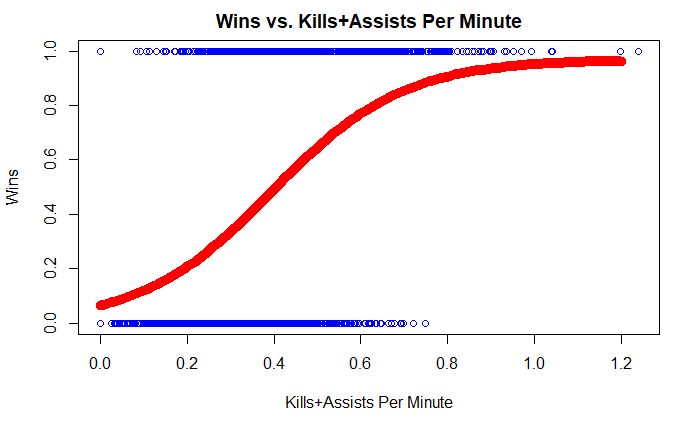

```r
x <- match_data$ka_per_min
p <- match_data$win
# Starting parameters chosen because that seemed to approximate data
nonlinear_model <- nls(p ~ a / (1 + exp(-b * (x - c))), start=c(a=1,b=10,c=0.4), control=nls.control(tol=1e-9))
plot(match_data$ka_per_min,match_data$win,main="Wins vs. Kills+Assists Per Minute",
     xlab="Kills+Assists Per Minute",ylab="Wins",
     col='blue')
curve(0.9684 / (1+exp(-6.6567*(x-0.3959))),from=0,to=1.2, col='red', lwd=10, add=TRUE)
```

Something that I found interesting was this plot in combination with a similar one. The next figure is a plot of my wins as a function of kills per minute of gametime (blue dots). Again, the red solid line is a fit to the data also to be taken to be the probability of winning.

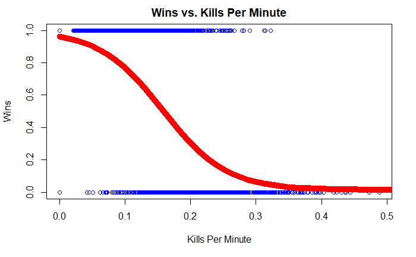

```r
x <- match_data$kills_per_min
p <- match_data$win
nonlinear_model <- nls(p ~ 1 - a / (1 + exp(-b * (x - c))), start=c(a=1,b=10,c=0.4), control=nls.control(tol=1e-9))
plot(match_data$kills_per_min,match_data$win,
     main="Wins vs. Kills Per Minute",
     xlab = "Kills Per Minute", ylab = "Wins",
     col="blue")
curve(1 - 0.9866 / (1+exp(-20.4909*(x-0.1577))),from=0,to=1.2, col='red', lwd=10, add=TRUE)
```

What I did not expect was that the kills per minute, which I thought would be a subset of kills + assists per minute, is actually negatively correlated with winning. Perhaps this could provide some insight as to what is happening with my gameplay. I’ll make the following observations:

1. Carries should be getting more kills per game.
2. A point for an assist is awarded if the target dies and you have dealt damage or applied a debuff to the target or you applied a buff to the killer of the target.

The first observation is both a prescriptive and a descriptive statement. Carries should be getting more kills per game because that allows them to secure a victory (prescriptive). Because we expect carries to become powerful over time, then it should be the case that they rack up kills as the game goes on (descriptive). But here it seems like that the more kills I have per game then I have a higher probability of losing. To explain this I can think of two scenarios:

1. As a non-carry hero, I am taking away kills from carries.
2. As a carry hero, I simply do not have the ability to secure a game.

The first point can be important because a kill for a hero grants reliable gold which can be used to buy better items or to buyback. Moreover, a kill streak counter builds up, so preventing a carry from building up this chain can stymie the flow of gold. I should point out that while stealing a kill point from a carry may not necessarily be the ideal situation, a carry that participates still obtains a non-negligible amount of gold, allowing the carry hero to build up over time. Moreover, a support hero can also build up his or her items to increase their survivability. The second point is important to consider because it could indicate the simple hypothesis that I cannot play carry heroes well.

```r
hist(carry$kills_per_min, main="Kills Per Minute", xlab="Kills Per Minute", ylab="Normalized density", freq = F, col=rgb(1,0,0,0.4))
hist(not_carry$kills_per_min, freq = F, col=rgb(0,0,1,0.4),add = T,legend=T)
```

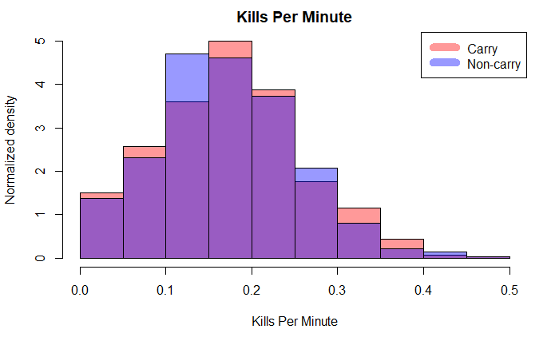

```r
legend("topright", c("Carry","Non-carry"), col=c(rgb(1,0,0,0.4),rgb(0,0,1,0.4)), lwd=10)
```

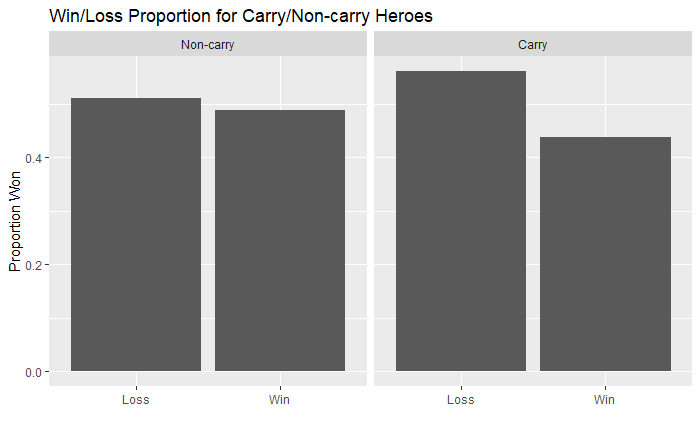

```r
ggplot(carry_data, aes(fill = win)) +
  geom_bar(aes(x = win, y = ..prop.., group = is_carry, fill = win)) +
  facet_wrap(~ is_carry) +
  ggtitle("Win/Loss Proportion for Carry/Non-carry Heroes") + labs(x="",y="Proportion Won")
```

Here, it is clear that indeed I am absolute garbage at playing a carry. On the other hand, it is clear from this plot and the kills + assists per minute graph that my strength lies in supporting. Support heroes tend to stay on the outskirts of battle and provide a smaller proportion of damage, particularly in the late game. For this reason, good supports ought to stay out of vision yet cast spells and do damage whenever possible. Objectively, I am still not great at this as evidenced by my losing record as non-carry heroes, but certainly my skill with non-carry heroes is clearly better than that for carry heroes.

# Conclusions

By examining a strange combination of data of wins as a function of kills and kills + assists per minute, I have determined that it is likely my inability to carry which is causing me to lose more games overall. With regards to what I ought to do, this does not mean that I should never carry. Rather, it simply means that I need to practice that role more.

### What can I do to practice the carry role?

There seems to be two confusing pieces of data here. First, there is the data which says that a higher kill count per minute is correlated with me losing. Second, there is the data that demonstrates that my kills per minute as a carry is as much as a non-carry. As a carry, I’m supposed to have a higher kill count, but it is ridiculous to say that if I work towards that goal then I will lose more. In fact, this knowledge should be used to infer a deeper problem: perhaps the fundamental issue is that even if I secure an advantage in terms of kills, I do not know how to lead the team to victory. Given an advantage in kills (and by proxy, gold and experience), it would be a good idea to work on encouraging the team to push to destroy the opposing team.

### Overall, what can I do to get a higher win rate?

From this data, it seems that if I continue to work as a team, particularly during teamfights, then it certainly helps to secure a win. Even as a carry, given that more kills + assists tends to lead to prosperous results, it ought to be a goal that I participate in teamfights. Knowing my own playstyle, I would admit that there are times when I am farming and not participating in a teamfight halfway across the map because I feel behind on farm. In those types of games, I notice that supports are never too far away from me in terms of levels, which should not happen if a carry is dominant. Of course, this has to be balanced with keeping a steady income so that I can survive and contribute to teamfights.